# GPU programming

A GPU (Graphical Processing Unit) is one of the many parts that make up your computer. It is similar to a CPU (Central Processing Unit) in that it can do calculations for you. Your computer probably has 2-4 cores/CPUs, and most standard Python only uses on of these. A GPU often has 512-1024 cores, and these are generally slower than CPU cores. However what the GPU cores lack in speed, they make up in numbers. GPUs are designed to do the same calculation many times in parallel, and in the right conditions can outperform CPU computing up to a couple orders of magnitude.

There are a couple of Python modules that enable you to run your code on the GPU. The module we will be using in this example is [numba](http://numba.pydata.org/), of which the GPU part relies on [NVIDIA CUDA](https://en.wikipedia.org/wiki/CUDA). Apart from GPU computing it also allows us to JIT (Just In Time) compile our python functions, which greatly increases performance.

The goal of this notebook will be to show the basics of GPU computing in Python using numba.

# The diffusion equation

## A textbook example of a parallelizable problem

The [diffusion equation](https://en.wikipedia.org/wiki/Diffusion_equation) is a PDE (Partial Differential Equation) that describes the change of concentrations (or temperature) of a material over time. Since the point of this notebook is to show CUDA, I'll give the steady state Jacobi iteration as is, if you are curious about its derivation you can check the wiki link: $$ c_{i, j}^{t + 1} = \frac{1}{4} (c_{i + 1, j}^{t} + c_{i - 1, j}^{t} + c_{i, j + 1}^{t} + c_{i, j - 1}^{t})$$ where $c_{i, j}^{t}$ is the concentration on point $(i, j)$, on timestep $t$.

[figure not shown]

Since diffusion is equal in all directions (in this example), this Jacobi iteration basically states that the concentration on point $(i, j)$ on the next timestep must be equal to the average of its four neighbours in the current timestep.

### domain

In this notebook we will solve a N*N square domain where on the top source there is a source of heat, and the left, right, and bottom edges are a sink.

# Code it

## VM (Virtual Machine) setup

We are currently on Google Colab, check [the docs](https://colab.research.google.com/) if you are curious what it is.

Before we get started we need to get GPU support through CUDA/numba

```python
#@title imports
# get CUDA support
!apt install -y --no-install-recommends -q nvidia-cuda-toolkit

# install numba
!pip3 install numba

# add the CUDA-toolkit and NVIDIA paths to the environment variables
import os
os.environ['NUMBAPRO_LIBDEVICE'] = "/usr/lib/nvidia-cuda-toolkit/libdevice"
os.environ['NUMBAPRO_NVVM'] = "/usr/lib/x86_64-linux-gnu/libnvvm.so"

# import packages and functions we want to use
from IPython.display import clear_output
from IPython.core.display import HTML
import numpy as np
from numba import jit, cuda, float32
%matplotlib inline
import matplotlib.pyplot as plt
import time

# clean up
clear_output()
```

## CPU

A naive approach to solve this problem would be to use our CPU. We can use the JIT compilation of numba to improve its performance (and to make a more fair comparison to the CUDA code). All we have to do is iterate over every combination of rows and column, add the values of its neighbours of the current time together, and store the result in a matrix for the next timestep.

```python
@jit()  # this decorator means we JIT compile this function, making it much faster
def jacobi_CPU(system_old, system_new):
    """
    Does one Jacobi iteration, sequantial and by CPU.
    Args:
        system_old: the system with its concentration values
        system_new: the system where the result will be stored
    """
    for row in range(1, system_old.shape[0] - 1):            # update for every row, start at one to not update boundary
        for col in range(1, system_old.shape[0] - 1):        # update for every column, start at one to not update boundary
            system_new[row, col] = 0.25 * (system_old[row + 1, col] + system_old[row, col + 1] +
                                           system_old[row - 1, col] + system_old[row, col - 1])
```

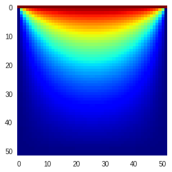

```python
#@title Result of jacobi_CPU
size = 50
system_a = np.zeros((size + 2, size + 2))
system_a[0] = 1
system_b = np.copy(system_a)

for _ in range(1000):
    jacobi_CPU(system_b, system_a)
    jacobi_CPU(system_a, system_b)

plt.imshow(system_b, cmap='jet')
plt.grid(False)
plt.show()
```

## GPU

The same function, but then ready to be executed on the GPU looks like this:

```python
@cuda.jit()  # this decorator means we JIT compile this function with CUDA, so it becomes a GPU function
def jacobi_GPU(system_old, system_new):
    """
    Does one Jacobi iteration, parallel and by GPU.
    Args:
        system_old: the system with its concentration values
        system_new: the system where the result will be stored
    """
    row, col = cuda.grid(2)  # get the position (row and column) on the grid
    row += 1; col += 1       # shift up one position, so we do not update the boundary conditions

    # make sure to be within the bounds of the system
    if 0 < row < system_old.shape[0] - 1 and 0 < col < system_old.shape[1] - 1:
        system_new[row, col] = 0.25 * (system_old[row + 1, col] + system_old[row, col + 1] +
                                       system_old[row - 1, col] + system_old[row, col - 1])
```

That looks very similar doesn't it? All we had to change is the decorator on the top of the function to compile it with CUDA, and instead of looping over every row and column, we have to get the row and column from the cuda.grid function. But what is this grid?

A GPU function is launched with a grid, which consists of a number of *blocks* and a number of *threads per block*, with its product being the total times the code is run. Our example of the heat equation exists of a 50 x 50 system, meaning our GPU function needs to be executed 2500 times. We could launch our function for instance with 2500 *blocks*, all consisting of one *thread*, 50 *blocks* with 50 *threads* each, or 1 *block* with 2500 *threads*. There is a max number of *threads per block*, there is practically no limit on the number of *blocks* you can start. It is often best to have to have a power of 2 number of threads, since threads mostly are executed per 32-64 (called warps).

A reasonable call to our GPU function would look like this:

```
jacobi_GPU[(4, 4), (16, 16)](old_system, new_system)
```

Here we start our function with 16 blocks, in 4 rows and 4 columns, and each block has 256 threads, in 16 rows and 16 threads. This results in the launch of 4 *16 = 64* threads *per row/column (see image), and a total of 64* 64 = 4096 threads. The cuda.grid() function is an function which tells the threads where they are on the grid. Since our grid is too large for our actual problem we have to check if we are not out of bounds in our gpu function. Since we do not want to worry about setting the correct grid size every time, we can make a helper function for this.

```python
def invoke_smart_kernel(size, threads_per_block=(16, 16)):
    """

    """
    blocks_per_grid = [(size + (tpb - 1)) // tpb for tpb in threads_per_block]
    return blocks_per_grid, threads_per_block
```

[figure not shown]

The GPU and CPU are located on different parts on the computer, and they do not share their memory (the CPU with its memory is often referred to as *host*, and the GPU and its memory as *device*). So when starting a GPU function the first thing you have to do is copy the function's code and its arguments from *host* to *device*. The GPU can then execute the function and when it is done it returns the result back to *host*. Since we want to execute our jacobi function numerous times before evaluating its result it might be smart to not keep sending our data back and forth between *host* and *device*. We can load our system onto the *device* with the function cuda.to_device(arr), and unload it with arr.copy_to_host(), saving us significant communication overhead.

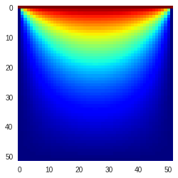

```python
#@title Jacobi gpu pipeline
size = 50

system_a = np.zeros((size + 2, size + 2))  # 2 larger for the edges
system_a[0] = 1                            # the source on the top
system_b = np.copy(system_a)

d_system_a = cuda.to_device(system_a)      # send the arrays to the device (gpu)
d_system_b = cuda.to_device(system_b)
for _ in range(1000):
    # iterate twice, reusing the arrays
    jacobi_GPU[invoke_smart_kernel(size)](d_system_b, d_system_a)
    jacobi_GPU[invoke_smart_kernel(size)](d_system_a, d_system_b)

system_b = d_system_b.copy_to_host()       # get the array from device to host

plt.imshow(system_b, cmap='jet')
plt.grid(False)
plt.show()
```

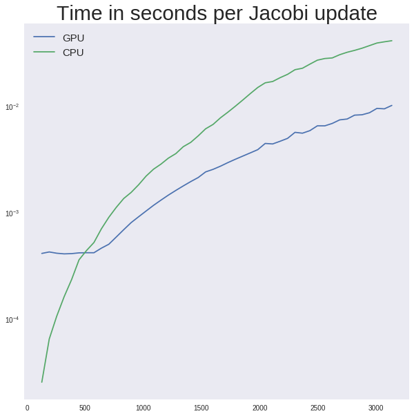

```python
#@title Performance difference
max_range = 50
stepsize = 64
repeats = 500
ranges = stepsize * np.arange(1, max_range)


GPU_times, CPU_times = [], []
for shape in ranges:
    system_shape = (shape + 2, shape + 2)
    system_CPU_a = np.zeros(system_shape)
    system_CPU_a[0] += 1
    system_CPU_b = np.copy(system_CPU_a)

    system_GPU_a = cuda.to_device(system_CPU_a)
    system_GPU_b = cuda.to_device(system_CPU_b)

    start_GPU = time.time()
    for _ in range(repeats):
        jacobi_GPU[invoke_smart_kernel(shape)](system_GPU_b, system_GPU_a)
        jacobi_GPU[invoke_smart_kernel(shape)](system_GPU_a, system_GPU_b)
    system_GPU_b = system_GPU_b.copy_to_host()
    end_GPU = time.time()

    start_CPU = time.time()
    for _ in range(repeats):
        jacobi_CPU(system_CPU_b, system_CPU_a)
        jacobi_CPU(system_CPU_a, system_CPU_b)
    end_CPU = time.time()

    GPU_times.append((end_GPU - start_GPU) / repeats)
    CPU_times.append((end_CPU - start_CPU) / repeats)

fig, ax = plt.subplots(figsize=(10, 10))


# we skim off the first since it is being compiled
plt.semilogy(ranges[1:], GPU_times[1:], label='GPU')
plt.semilogy(ranges[1:], CPU_times[1:], label='CPU')
plt.title(f"Time in seconds per Jacobi update", fontsize=30)
plt.legend(fontsize=15)
plt.grid(False)

plt.show()
```

# Concluding remarks

This was a simple introduction to CUDA programming with Python. For more advanced help check the [CUDA C/C++ programming guide](http://docs.nvidia.com/cuda/cuda-c-programming-guide/index.html) and the [numba CUDA docs](http://numba.pydata.org/numba-doc/dev/cuda/index.html).